# Introduction to RavenR

Robert Chlumsky, Dr. James R. Craig

May 9, 2022

# Introduction to RavenR Tutorial

This short document is intended to get you started with using `RavenR` to aid your analysis with the Raven Hydrologic Modelling Framework. This tutorial will get you up and running with the `RavenR` package and comfortable running a few commands. Some knowledge or R is presumed in this document. If you are not comfortable with R, take a look at any number of R training and Introductory resources, such as the [tRaining repository](https://github.com/rchlumsk/tRaining)) on Github.

This exercise will use the Nith River modelled output available from within the RavenR package, thus the functions to read in data from csv files are not required. However, it is recommended that you download the Nith river model files, and try to both run the model and read in the output files. The Nith river model can be downloaded from the [Raven Tutorial #2](https://raven.uwaterloo.ca/Downloads.html).

Note that the `RavenR` package is focused on handling Raven input/output files, model diagnostics, and generating plots with the `ggplot2` library. The dependencies required by the package are kept at a relative minimum to preserve stability. An additional package, `RavenR.extras`, is available on [Github](https://github.com/rchlumsk/RavenR.extras) and contains additional functionality.

## Getting Acquainted with RavenR

If you don’t have RavenR yet installed in your R library, run the following commands to install the RavenR package directly from the Comprehensive R Archive Network (CRAN), which is available on [CRAN](https://CRAN.R-project.org/package=RavenR).

```r
install.packages("RavenR")
```

For those interested in the latest versions of RavenR or in contributing to the development of RavenR, the package may be found on [Github](https://github.com/rchlumsk/RavenR) at https://github.com/rchlumsk/RavenR. Packages on Github may also be installed from within R using the `devtools` library with the code below.

```r
# install.packages("devtools")
library(devtools)
devtools::install_github("rchlumsk/RavenR")
```

Load the RavenR library from the console and view its contents with the following commands:

```r
library(RavenR)

# view first 20 functions in RavenR
ls("package:RavenR") %>%
  head(., 20)
```

[output not shown]

Each function in the package is documented, which includes a description of the function, its inputs and outputs, and an example. You can look at any of the function examples by typing out the name of the function beginning with a question mark, which will show the help information at the right of the RStudio environment.

```r
?rvn_flow_scatterplot
```

The name of each external function in the RavenR package begins with the “rvn_” prefix, so you in practice ‘search’ for functions by beginning to type them out. Try this to see what functions are available with “rvn_rvh_”.

## Sample Data in RavenR

The RavenR package contains a number of sample data files, which are useful for training purposes and testing of functions. The package contains sample data both in R format (under RavenR/data) and as raw data files in their native formats (RavenR/inst/extdata). The sample data set from the RavenR package (in R format) can be loaded in using the data function (with either quotes or just the name of the data), e.g.,

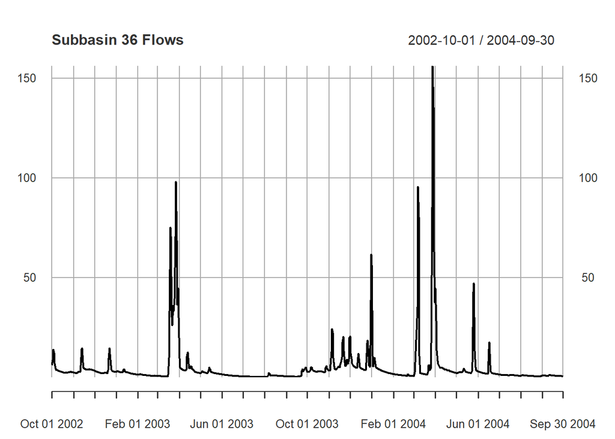

```r
data("rvn_hydrograph_data")
# ?rvn_forcing_data
plot(rvn_hydrograph_data$hyd$Sub36,
     main="Subbasin 36 Flows")
```

Notice as well that the sample data set in R format also has a built in help file to describe the data.

To locate the raw data from the RavenR package, we will use a syntax to find the data by file name in the RavenR package directory, which ends up looking more similar to a raw file call. This raw data file comes from the **inst/extdata** folder in the RavenR package. Note that this is done so that the sample data in raw format can be used and tested with functions, and the syntax to locate the data file is more portable across various computer operating systems.

```r
# read in hydrograph sample csv data from RavenR package
ff <- system.file("extdata","run1_Hydrographs.csv", package = "RavenR")

# ff is a simple string, which can be substituted with any file location
ff
```

```
## [1] "C:/Users/rober/AppData/Local/Temp/Rtmp84E2QL/Rinst43943c751a4e/RavenR/extdata/run1_Hydrographs.csv"
```

```r
# read in sample rvi file from the RavenR package
rvi_file <- system.file("extdata", "Nith.rvi", package = "RavenR")

# show first 6 lines of the file
readLines(rvi_file) %>% head()
```

```
## [1] "# ----------------------------------------------"
## [2] "# Raven Input file"
## [3] "# HBV-EC Nith River emulation test case"
## [4] "# ----------------------------------------------"
## [5] "# --Simulation Details -------------------------"
## [6] ":StartDate       2002-10-01 00:00:00"
```

The `system.file` command will simply build a file path for where this data file is located on your machine with the RavenR package installation, which can then be passed to any function as required to provide a file location. This command will be used throughout this tutorial in place of local files for portability, however, your own data files may be swapped in place of the system.file locations. For example, you may wish to pass files from other Raven Tutorial files by changing the file paths throughout this tutorial.

## Diagnostics and Plotting

Now you are ready to start using RavenR to directly visualize and manipulate model output. This section of the exercise will make use of raw sample data in the RavenR package to illustrate some of the diagnostics and plotting capabilities of RavenR.

### Forcing Functions

Start by finding the raw **run1_ForcingFunctions.csv** file with the `system.file` command. Note that this can be replaced with your own forcing functions file location if preferred. We will store the forcing functions data into an object called ff (and obtain just the subobject using the ‘$’ operator), and then view the first few rows using the **head** function. We will show only the first six columns of the data for brevity.

```r
ff <- system.file("extdata","run1_ForcingFunctions.csv", package = "RavenR")
# ff <- "C:/TEMP/Nith/output/ForcingFunctions.csv" # replace with your own file
ff_data <- RavenR::rvn_forcings_read(ff)
head(ff_data$forcings[,1:6])
```

```
##            day_angle     rain snow    temp temp_daily_min temp_daily_max
## 2002-10-01   4.70809 3.468690    0 22.5956       17.92510        27.2662
## 2002-10-02   4.70809 3.468690    0 22.5956       17.92510        27.2662
## 2002-10-03   4.72530 1.189180    0 19.2076       15.40780        23.0075
## 2002-10-04   4.74251 2.083260    0 13.3714       11.49870        15.2440
## 2002-10-05   4.75973 6.474310    0 19.0304       12.50970        25.5510
## 2002-10-06   4.77694 0.125591    0 11.0186        7.43466        14.6024
```

Now we can plot the forcing data using the rvn_forcings_plot function. This creates an output of the five main forcings from the data set, from which we can plot one or more forcings, including a plot of the whole set of plots. This is typically a reasonable reality check on the model forcings.

Here, we plot the PET from the set of created plots.

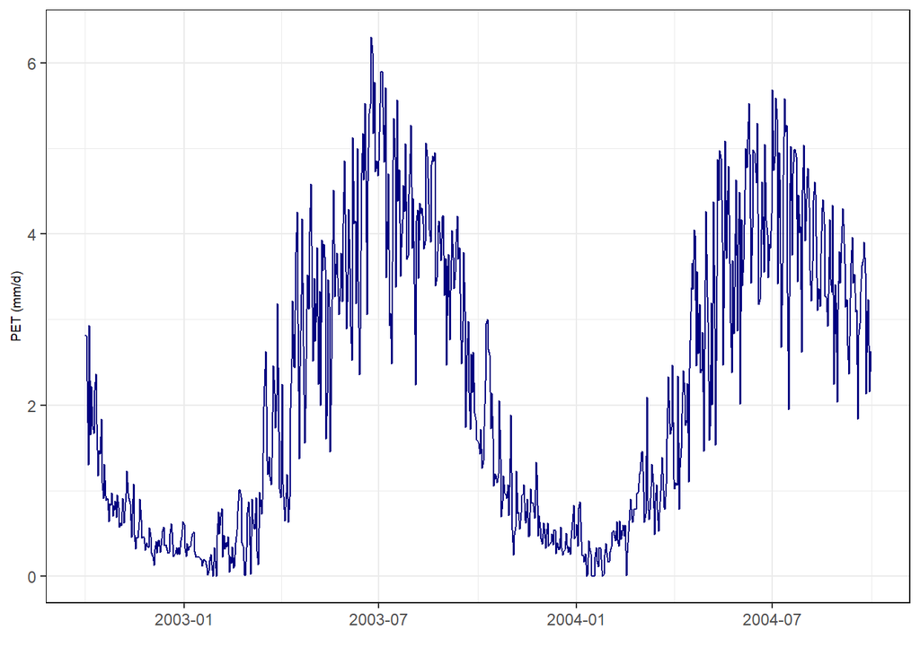

```r
myplots <- rvn_forcings_plot(ff_data$forcings)
# myplots$Temperature
# myplots$Radiation
# myplots$AllForcings
myplots$PET
```

The legend for the forcing plot functions is turned off by default, but can be added back in using the `theme` function from `ggplot2` to add the legend to the plot.

```r
library(ggplot2)
myplots <- rvn_forcings_plot(ff_data)
```

```
## passed forcings as list, disaggregating forcings
```

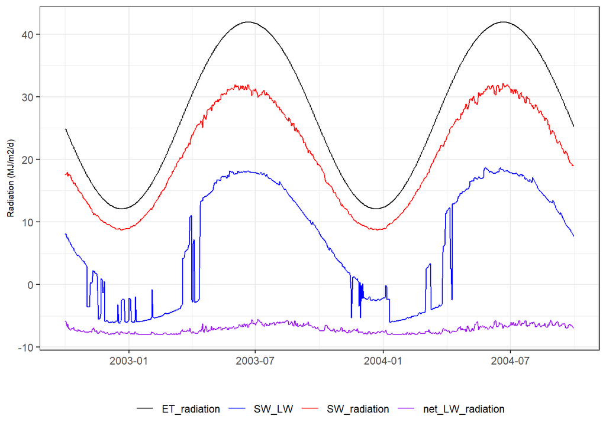

```r
myplots$Radiation +
  theme(legend.position = "bottom")
```

### Hydrograph and Diagnostics

We can similarly access the hydrograph fit. Here the hydrograph sample data is located with the usual `system.file` command, then read into R with the `rvn_hyd_read` function intended for reading Hydrographs file. The flows from a specific subbasin can be extracted using the `rvn_hyd_extract` function, which is done here for subbasin 36. The precipitation can be extracted similarly.

```r
ff <- system.file("extdata","run1_Hydrographs.csv", package = "RavenR")
# ff <- "mydirectory/Hydrographs.csv" # replace with your own file
hy <- rvn_hyd_read(ff)
head(hy$hyd)
```

```
##              precip    Sub36 Sub36_obs    Sub43 Sub43_obs
## 2002-10-01       NA  5.96354        NA 11.25050        NA
## 2002-10-02 3.468690 11.96430     0.801 18.59070      3.07
## 2002-10-03 1.189180 15.43700     0.828 25.74430      2.99
## 2002-10-04 2.083260  8.76948     0.860 18.68610      3.06
## 2002-10-05 6.474310  4.66501     0.903  9.82648      2.93
## 2002-10-06 0.125591  4.20829     1.040  7.90952      3.15
```

```r
flow36 <- rvn_hyd_extract("Sub36",hy)
precip <- hy$hyd$precip
```

The hydrograph object flow36 now stores the simulated hydrograph (`flow36$sim`) and the observed hydrograph (`flow36$obs`), and the null subobject (`flow36$inflow`). The precip object stores the entire time series of watershed-averaged precip (`precip$sim`). We can plot the simulated and observed hydrograph with the following commands in base R, extracting the date:

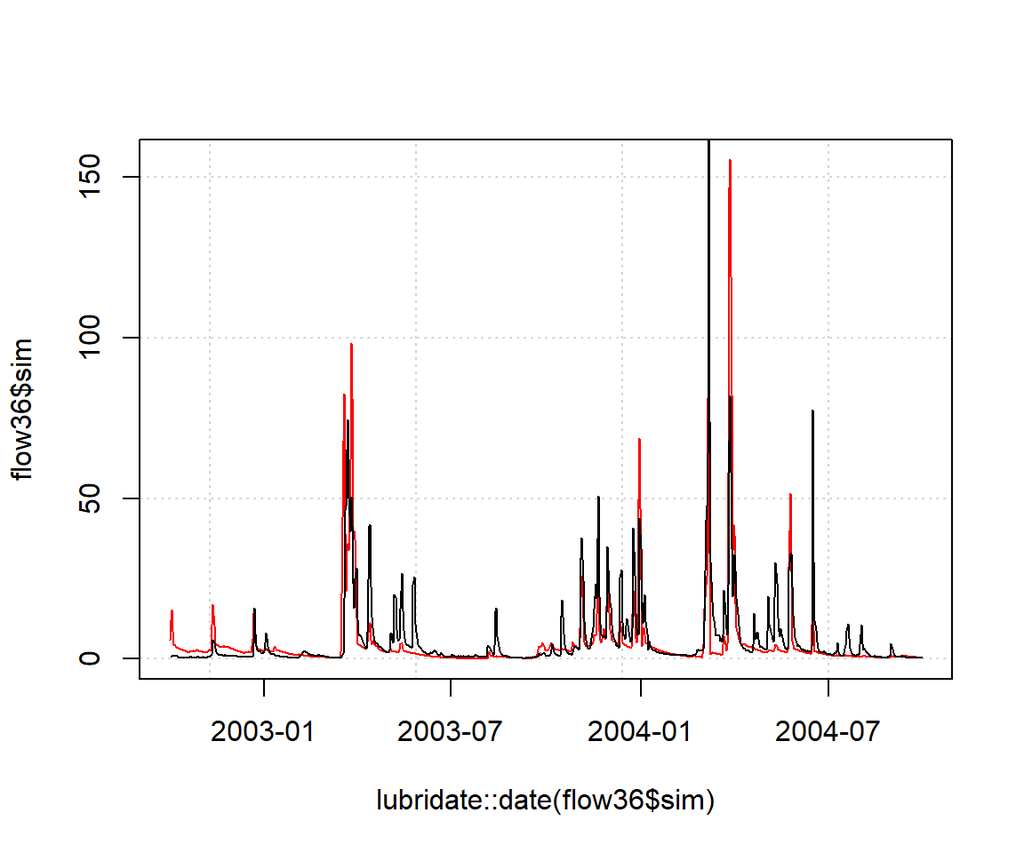

```r
plot(lubridate::date(flow36$sim), flow36$sim,col='red',
     type='l', panel.first=grid())
lines(lubridate::date(flow36$obs), flow36$obs,col='black')
```

A ggplot format plot can also be created using the `rvn_hyd_plot` function in the RavenR library. This function can save some of the trouble of plotting the precipitation on the secondary axis.

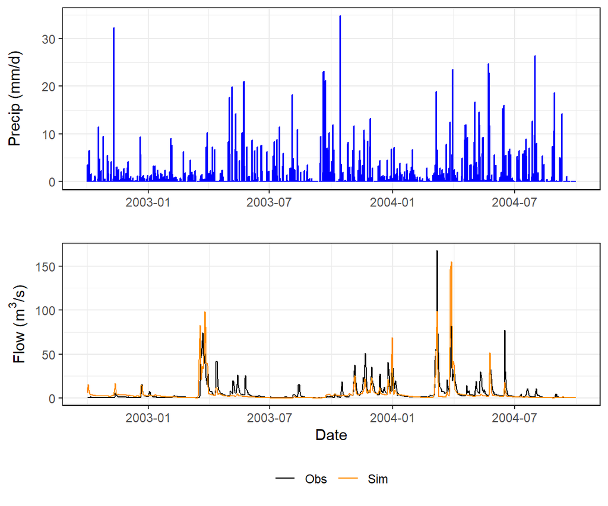

```r
rvn_hyd_plot(sim=flow36$sim, obs=flow36$obs, precip = precip)
```

There are some other helpful functions in RavenR for understanding our hydrographs. For example, the ‘spaghetti’ plot overlays the hydrographs from the supplied series and plots them against day of year on the x-axis, facilitating a comparison across multiple years.

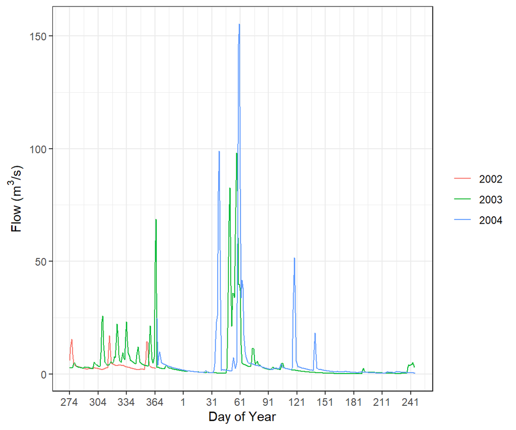

```r
rvn_flow_spaghetti(flow36$sim)
```

The annual quantiles function compute the flow quantiles for a given time series for each day of the year, and plot those quantiles with the corresponding plot function. This provides a similar look to the spaghetti plot, but with smooth quantiles instead of overlaying time series.

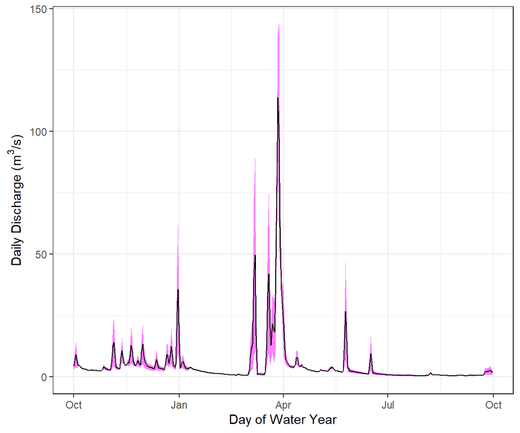

```r
rvn_annual_quantiles(flow36$sim) %>%
  rvn_annual_quantiles_plot(., ribboncolor = 'magenta')
```

Other plots indicate the agreement between peak flows in the modelled and observed.

```r
rvn_annual_peak(flow36$sim, obs = flow36$obs)
```

```
## $df_peak
##     date.end sim.peak obs.peak
## 1 2003-09-30  98.1327     74.4
## 2 2004-09-30 155.3560    168.0
##
## $p1
```

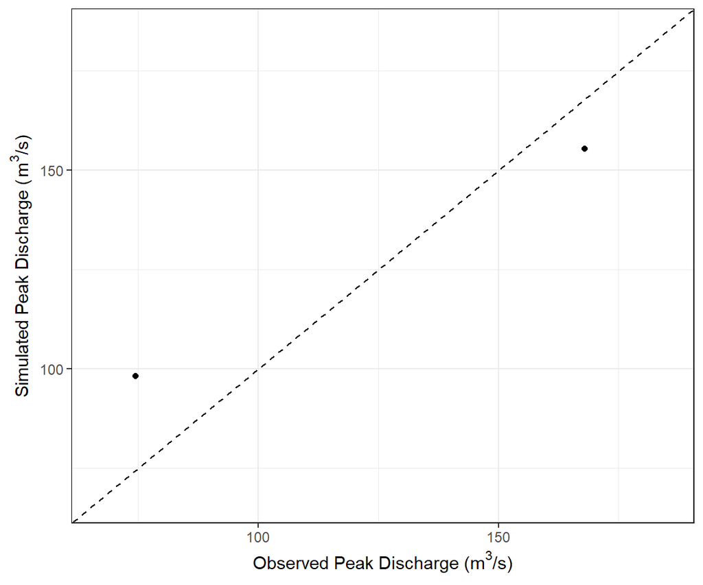

```r
rvn_annual_peak_event(flow36$sim, obs = flow36$obs)
```

```
## $df_peak_event
##    obs.dates sim.peak.event obs.peak.event
## 1 2003-03-23        35.7503           74.4
## 2 2004-03-07        98.9858          168.0
##
## $p1
```

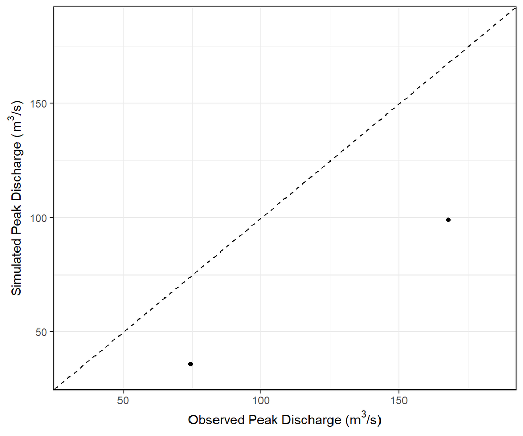

We can also use some of the Raven plots to get some diagnostics and comparisons on the simulated and observed hydrographs. For example, the plots below compare the annual cumulative flow and the monthly volume bias, respectively.

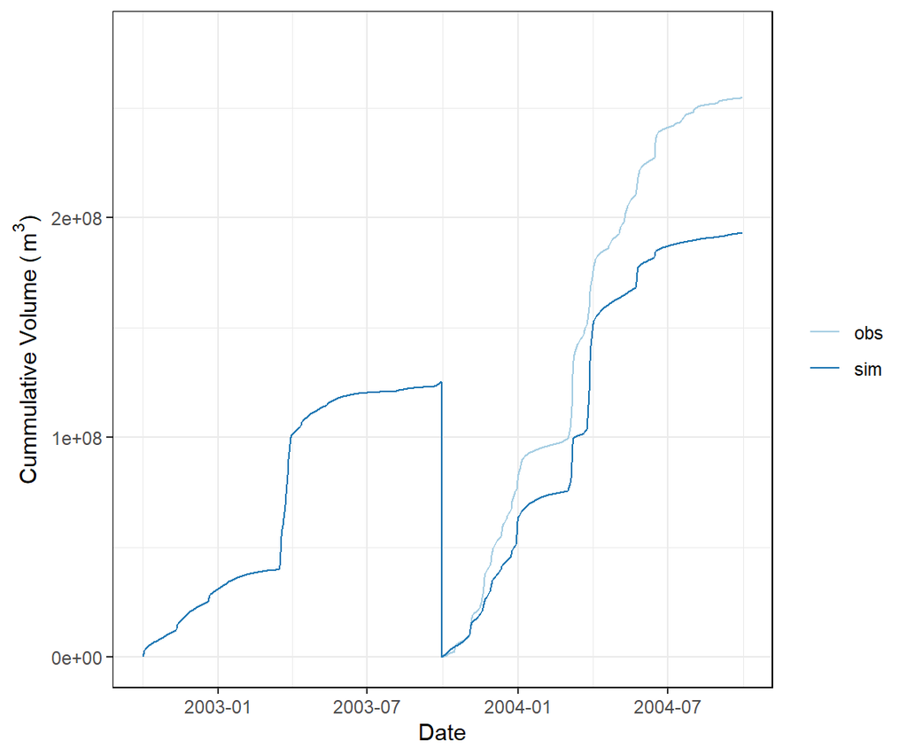

```r
rvn_cum_plot_flow(flow36$sim, obs = flow36$obs)
```

```r
rvn_monthly_vbias(flow36$sim, obs = flow36$obs)
```

```
## $df.mvbias
##         mvbias
## Jan  14.218038
## Feb -31.634886
## Mar  15.934117
## Apr -36.526804
## May -61.526206
## Jun -55.782838
## Jul -69.457872
## Aug -70.455088
## Sep  35.169824
## Oct   1.325446
## Nov  83.761819
## Dec  29.171061
##
## $plot
```

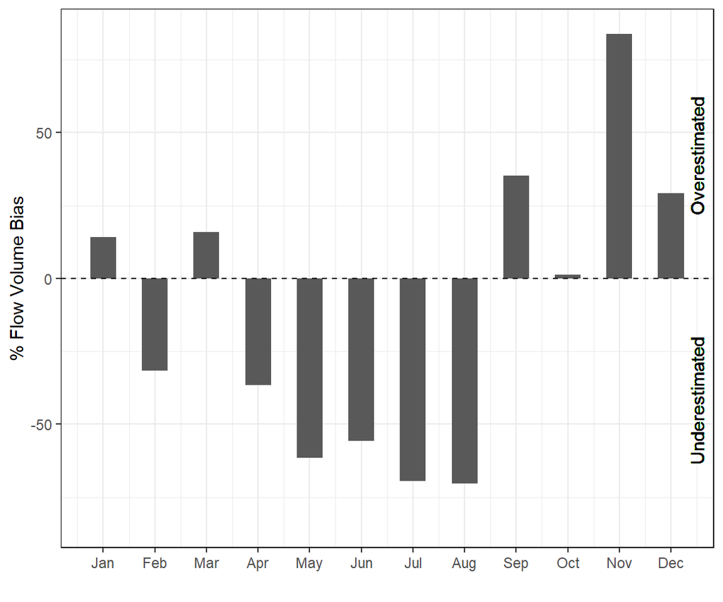

### Flow DyGraphs

A fun feature in the RavenR package is the addition of dygraphs, which produces a dynamic hydrograph plot with a slider on the time scale. This is particularly helpful for viewing subsections of a hydrograph dynamically, and comparing the simulated and observed hydrographs in an interactive environment. Only the output object from the `rvn_hyd_read` function and the name of headings to extract is required. Note that this interactive plot does not work well in a PDF file, so try this out in R/RStudio.

```r
library(htmltools)

rvn_hyd_dygraph(hy, basins="Sub36") %>%
htmltools::tagList()
```

While this tutorial focuses on the forcing functions and hydrograph data, similar routines exist for reading in the reservoir stages output, the watershed mass energy balance files, and other Raven outputs.

### RavenR Time Series Utilities

One utility that does not exist in the `xts` package, but is nonetheless useful in hydrology, is the application of functions to the water year period rather than the calendar year. In the RavenR package, the `rvn_apply_wyearly` function accomplishes this. The water year is by default set to index by the October 1st water year (specifying the period ending September 30th), but this may be provided as an argument to the function for different water years. Here, we apply the mean function to the water year using sample hydrograph data in RavenR.

```r
myhyd <- system.file("extdata","run1_Hydrographs.csv", package = "RavenR") %>%
  rvn_hyd_read()

library(xts)

# apply mean to calendar year in hydrograph data
xts::apply.yearly(myhyd$hyd$Sub36, colMeans, na.rm = TRUE)
```

```
##               Sub36
## 2002-12-31 3.886438
## 2003-12-31 4.962424
## 2004-09-30 5.549967
```

```r
# apply mean as FUN to daily average temperature
RavenR::rvn_apply_wyearly(myhyd$hyd$Sub36, colMeans, na.rm = TRUE)
```

```
##               Sub36
## 2003-09-30 3.994746
## 2004-09-30 6.096847
```

## RVI File Utilities

The RavenR package can read the rvi file and generate a network plot of the model connections, which is helpful in understanding the model configuration. This can be done as follows, again using the Nith rvi file as an example. The network plot may be directly written to file by supplying a file name to the `pdfout` argument, which is NULL by default. Similar functionality is also available with the `rvn_rvi_process_diagrammer` function, which uses the `DiagrammeR` library.

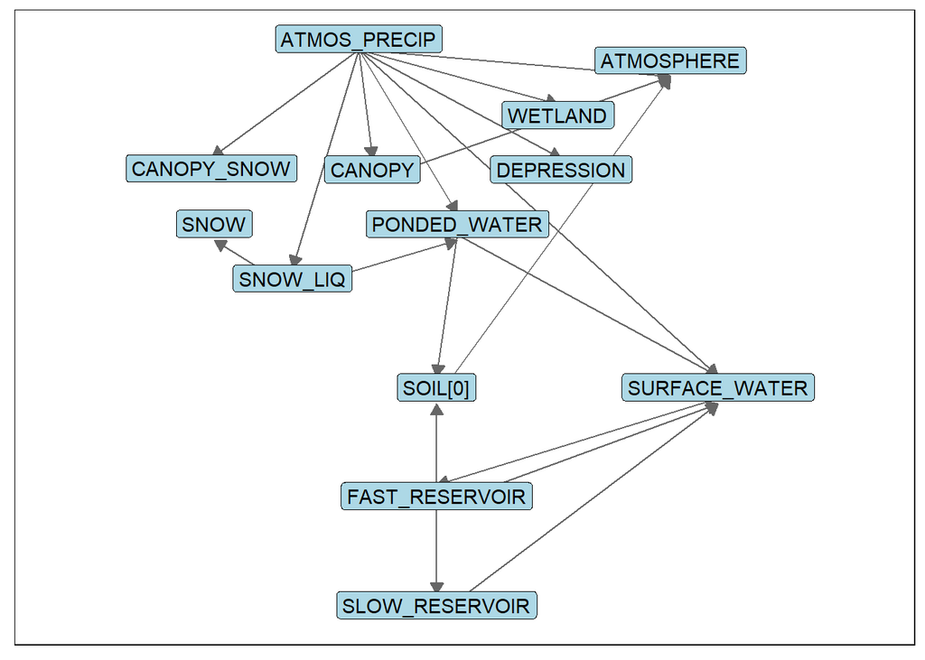

```r
rvi <- rvn_rvi_read(system.file("extdata","Nith.rvi", package = "RavenR"))

rvn_rvi_connections(rvi) %>%
  rvn_rvi_process_ggplot()
```

The Raven User’s Manual (Appendix D) provides a number of model templates that can be used to emulate existing model structures or act as starting points for modellers to then adapt to their applications. The `rvn_rvi_write_template` function allows these templates to be written directly to an rvi file, which reduces the effort in creating these initial template files.

We can call this command to create a template rvi file for one of these models as per below.

```r
td <- tempdir() # temporary directory to write model files to
tf <- file.path(td,"mymodel.rvi")

rvn_rvi_write_template(template_name="HMETS",
                       filename=tf,
                       author="Your Name")
```

```
## [1] TRUE
```

This file can also be used in the rvp file tools to quickly develop parameter files based on the model structure, discussed in the RVP section.

## RVH File Utilities

The discretization file, rvh, may be read in and modified using the RavenR package. The `rvn_rvh_read` function also computes the upstream area of each subbasin. The corresponding `rvn_rvh_write` function also writes the rvh object back to file.

```r
# read in rvh file
rvh <- rvn_rvh_read(system.file("extdata","Nith.rvh", package = "RavenR"))

rvh$SBtable[, c("SBID","Downstream_ID","Area","TotalUpstreamArea")]
```

```
##    SBID Downstream_ID  Area TotalUpstreamArea
## 30   30            36 318.5             318.5
## 36   36            39 219.2             537.7
## 39   39            43 271.7             809.4
## 43   43            -1 205.0            1014.4
```

Similar to the rvi functionality, the subbasin connections from the rvh file may be plotted using one of two ways. The `rvn_rvh_read` function has built-in functionality to build a network plot, which may be plotted directly. The `rvn_rvh_subbasin_network_plot` function uses the subbasin table to plot the network from the lat/long coordinates, generating a more spatially accurate plot.

Compare these two plots to the map of the Nith basin from Tutorial #2.

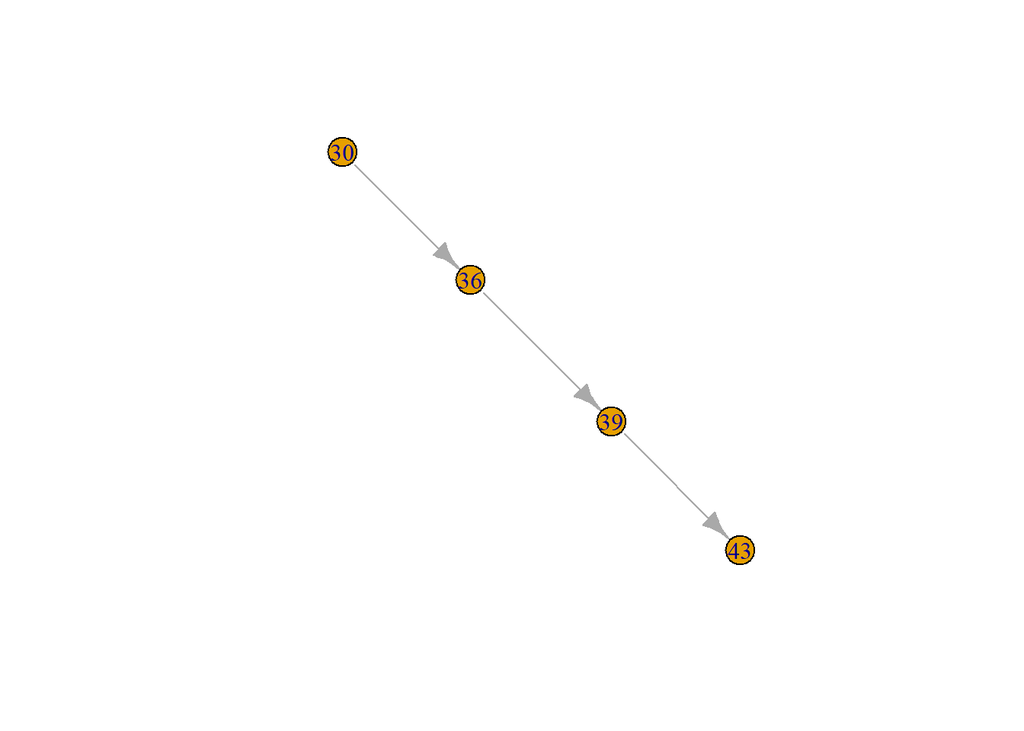

```r
# plot network from rvh file directly
plot(rvh$SBnetwork)
```

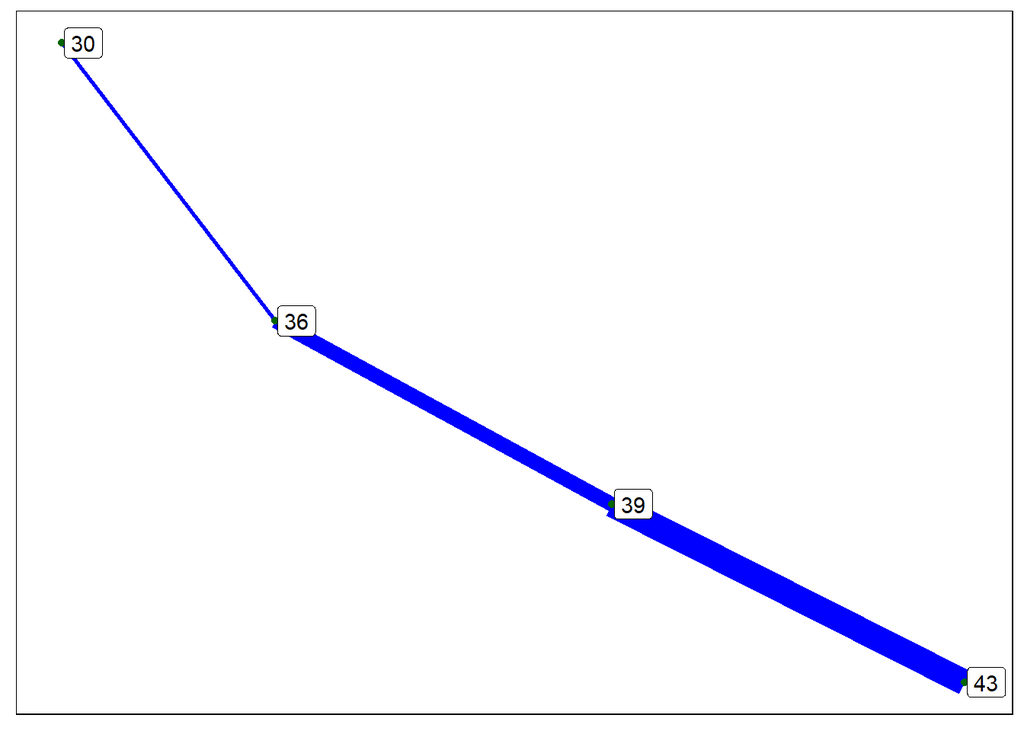

```r
# create network plot of watershed structure from rvh file
rvn_rvh_subbasin_network_plot(rvh$SBtable, labeled = TRUE)
```

Another useful rvh functionality is the simplification of an HRU file. Often in the initial HRU discretization, many HRUs with similar properties and/or very small areas exist that are worthwhile consolidating for the purpose of modelling. The `rvn_rvh_cleanrhus` function accomplishes this. Try the example in the help file - `?rvn_rvh_cleanhrus`.

Finally, rvh files can be created with the `rvn_rvh_write` function, and the basic subbasin table and hru table can be created with the `rvn_rvh_blankSBdf` and `rvn_rvh_blankHRUdf` functions, respectively. More complex discretizations would require some manual editing or other discretization tools to first create this network.

## RVP Utilities

A number of useful rvp utilities may be found in the RavenR package by searching for `?rvn_rvp_`. A useful workflow to create initial rvp files based on the Raven templates is available, and demonstrated below in a few steps.

An rvp template file could be generated by running Raven with the `:CreateRVPTemplate` option in Raven.

```r
rvn_run(fileprefix = "mymodel",
        indir=td, # temporary directory created earlier
        outdir=td, # write to same temporary directory
        rvi_options=":CreateRVPTemplate",
        showoutput = TRUE)
```

From the rvp template file, the file can be infilled to a usable rvp file using default values for parameter values and the various classes and other information from the rvh file. Additional rvp options can be added as well, such as average annual runoff and redirect file commands.

```r
# temporary file path
tf <- tempfile()

# infill template file with default parameter values
rvn_rvp_fill_template(
                      rvi_file = system.file("extdata","Nith.rvi", package = "RavenR"),
                      rvh_file = system.file("extdata","Nith.rvh", package = "RavenR"),
                      rvp_template_file = system.file("extdata","nithmodel.rvp_temp.rvp", package = "RavenR"),
                      avg_annual_runoff = 123,
                      extra_commands=":RedirectToFile  channel_properties.rvp",
                      rvp_out = tf)
```

```
## [1] TRUE
```

A table of default values and ranges for parameters required in a model may be obtained by use of the `rvn_rvi_getparams` function, which reads the rvi file and uses the database files stored with the RavenR installation to query any required parameters and their information. This is demonstrated for the Nith model file below.

```r
system.file("extdata","Nith.rvi", package = "RavenR") %>%
  rvn_rvi_read() %>%
  rvn_rvi_getparams() %>%
  head() # preview of parameter data frame
```

```
##               param class_type     units  auto default min max
## 1   FOREST_COVERAGE       LULT    [0..1] False       0   0   1
## 5  IMPERMEABLE_FRAC       LULT    [0..1] False     0.0   0   1
## 13  REFREEZE_FACTOR       LULT [mm/dC/d] False    5.04 0.0  10
## 37         POROSITY       SOIL    [0..1]  True     0.4 0.0   1
## 42   PET_CORRECTION       SOIL    [0..1]  True     1.0 0.0   1
## 43   FIELD_CAPACITY       SOIL    [0..1]  True     0.0 0.0   1
```

## RVT File Utilities

Here, we use sample data from the `tidyhydat` function, and write this to an rvt file for use within a Raven model. The commands that would be used to extract data with the `tidyhydat` function is also provided below (but commented out). The sample data is used here to help meet compliance, but you are encouraged to try using the `tidyhydat` commands to try this functionality for yourself.

```r
stations <- c("05CB004","05CA002")

## Gather station data/info using tidyhydat functions
# library(tidyhydat)
# hd <- tidyhydat::hy_daily_flows(station_number = stations,
#  start_date = "1996-01-01", end_date = "1997-01-01")

## load RavenR package sample data
data(rvn_tidyhydat_sample)
hd <- rvn_tidyhydat_sample

tf1 <- file.path(tempdir(), "station1.rvt")
tf2 <- file.path(tempdir(), "station2.rvt")

# Create RVT files
rvn_rvt_tidyhydat(hd, subIDs=c(3,11),
  filename=c(tf1,tf2))

# preview first 6 lines of rvt file 1
readLines(tf1) %>% head()
```

[output not shown]

Similar support for the `weathercan` package to write gauge forcing data exists within the `RavenR` package through the `rvn_rvt_write_met` function. The `rvn_rvt_write_met` function supports writing of all valid Raven forcing information, and will write all supplied (valid) data to rvt file. Here, we use the function to write the total precipitation, maximum daily temperature, and minimum daily temperature from the ‘Kamloops A’ station to a Raven-compliant rvt format. The station metadata, also required for Raven gauge forcing data, is written to a separate file. The sample data within RavenR is used once again, this time using the sample data obtained from the `weathercan`. However, you are encouraged to try obtaining the data from the `weathercan` package directly using the commented out commands below.

```r
## Obtain data using the weathercan package
# library(weathercan)
# kam <- weather_dl(station_ids = 51423,
#                   start = "2016-10-01", end = "2019-09-30", interval="day")

## load RavenR package sample data
data(rvn_weathercan_sample)
kam <- rvn_weathercan_sample

fpath1 <- file.path(tempdir(), "met_data.rvt")
fpath2 <- file.path(tempdir(), "met_gauges.rvt")

## basic use, provide temporary file names for writing
## filter for particular columns to write to file
result <- kam[,c("station_name","date","lat","lon","elev","max_temp","min_temp","total_precip")] %>%
            rvn_rvt_write_met(metdata = .,
                        filenames = fpath1,
                        filename_stndata = fpath2)
```

```
## [1] "Imported data from 1 station"
```

```r
# preview files
readLines(fpath1) %>% head() # data rvt file
```

```
## [1] ":MultiData"
## [2] "  2016-10-01 00:00:00 1 1095"
## [3] "  :Parameters TEMP_MAX TEMP_MIN PRECIP"
## [4] "  :Units DegC DegC mm/d"
## [5] "  16.8 5.5 0"
## [6] "  18.1 2.5 0"
```

```r
readLines(fpath2) %>% head() # gauge data file
```

```
## [1] ":Gauge KAMLOOPS_A"
## [2] "  :Latitude 50.700000"
## [3] "  :Longitude -120.450000"
## [4] "  :Elevation 345.30"
## [5] "  :RedirectToFile C:\\Users\\rober\\AppData\\Local\\Temp\\RtmpsRlKdS/met_data.rvt"
## [6] ":EndGauge"
```

# Exercise 1 - Build a model workflow

Now we will build a simple script which will provide a number of visualizations, which we can use to look at the Nith river model each time we run it. This can be made as complex as you want. You may also choose to run this for a different Raven model as part of this exercise.

## Building a model workflow script

Start with a new script. From RStudio, go to the main menu. `Choose File -> New File -> R Script`. Populate the script with the following.

You can find the Nith model files in the Raven Tutorials. Please place a Raven.exe executable (or symbolic link called Raven.exe) inside this Nith folder, and update the modelfolder variable below to the appropriate folder location on your system.

```r
modelfolder <- "C:/TEMP/Nith/"  # model folder with Raven.exe and Nith model files
fileprefix <- "Nith"            # prefix for model files (i.e. Nith.rvi should be in the modelfolder)
outdir <- "./output/"

## if this generates an error for you, the Nith folder cannot be found.
# Please update the modelfolder variable accordingly
if (!dir.exists(modelfolder)) {
  stop(sprintf("The folder %s does not exist, please verify!", modelfolder))
  }

setwd(modelfolder)

# RUN RAVEN
# =====================================================
# writes complete command prompt command (Windows)
# > Raven.exe [filename] -o [outputdir]
RavenCMD <- sprintf("Raven.exe %s -o %s", fileprefix, outdir)

# or adjust string if in a macos/ linux environemnt
# RavenCMD <- sprintf("./Raven.exe %s -o %s", fileprefix, outdir)

system(RavenCMD) # this runs raven from the command prompt
```

Once the model is run, we can read in the output and save some of the plots to file. Here, we examine the forcing data and the snowpack.

```r
# GENERATE OUTPUT PLOTS
# =====================================================
# read in the model output files

## use ggsave from ggplot2 to save plot pdf
ff_data <- rvn_forcings_read(paste0(outdir,"run1_ForcingFunctions.csv"))
myplots <- rvn_forcings_plot(ff_data$forcings)
myplots$AllForcings %>%
  ggsave("Forcings.pdf", ., width = 8.5, height=11, units='in')

# plot snowpack from xts format, save using base R commands
mywshd <- rvn_watershed_read(paste0(outdir, "run1_WatershedStorage.csv"))
png("snowpack.png") # create a png file to direct plot to
plot(mywshd$watershed_storage$Snow,
     main='Snowpack (mm SWE)', col='blue')
dev.off() #finishes writing plot to .png file
```

## Modify the script

Modify the above script to generate png image plots of monthly subbasin-averaged PET in Subbasin 43 using the :CustomOutput option (you will have to add a :CustomOutput command to the Raven input rvi file). You will also want to use the RavenR `rvn_custom_read()` and `rvn_custom_output_plot()` commands.

Then, add a set of diagnostic plots related to the Hydrographs.csv file. For example, you may wish to compare annual peaks in the data or flow volumes.

# Exercise 2 - Build Raven Input rvt Files

If you have completed the workflow exercise above, you may build on the Introduction to R exercise from the earlier session to build Raven-compliant input files for the Raven River in Alberta. Using your knowledge of R and RavenR, undertake the following tasks using only R and a text file editor.

- build an rvt file of daily observed hydrograph flows from the Raven River WSC gauge; and
- build rvt file(s) for at least one daily meteorological gauge located close to the WSC gauge (within 10km).

Based on the meteorological information in the station(s), would there be sufficient meteorological information to run a model of the Raven River? What else would be required?

# Exercise 3 - Build Additional Raven Input files

Following up from Exercise 2, let’s say that we want to continue building model files for Raven River, continuing with an rvi, rvh and rvp file. We can use the `rvn_rvi_write_template` file and the other utilities for rvi/rvp files to create these two files directly with the RavenR package. We can also create a basic rvh file with assigned properties in R with the RavenR package.

For this exercise, you should do the following. Create any new model files with the prefix “ravenriver”, for example, “ravenriver.rvi”.

1. Select a model template option for the `rvn_rvi_write_template` function, and create the file ravenriver.rvi with this template.
2. Create the rvp template file using Raven, called in R or otherwise.
3. Create a basic rvh file called ravenriver.rvh with 1 subbasin and 2 HRUs.
4. Create an infilled rvp file called ravenriver.rvp from the rvp template file using RavenR.

# Conclusion

This tutorial is meant to serve as a brief introduction to the RavenR package. If you have any comments, suggestions or bug reports, please leave a note on the issues page of the Github project ([RavenR Github page](https://github.com/rchlumsk/RavenR)), email the authors of the package, or feel free to let us know on the [Raven forum](https://raven.uwaterloo.ca/).

Additional Raven materials can be found on the [Raven downloads page](https://raven.uwaterloo.ca/Downloads.html), and additional RavenR vignettes can be found on Github in the [vignettes folder](https://github.com/rchlumsk/RavenR/tree/master/vignettes).